# Week 3

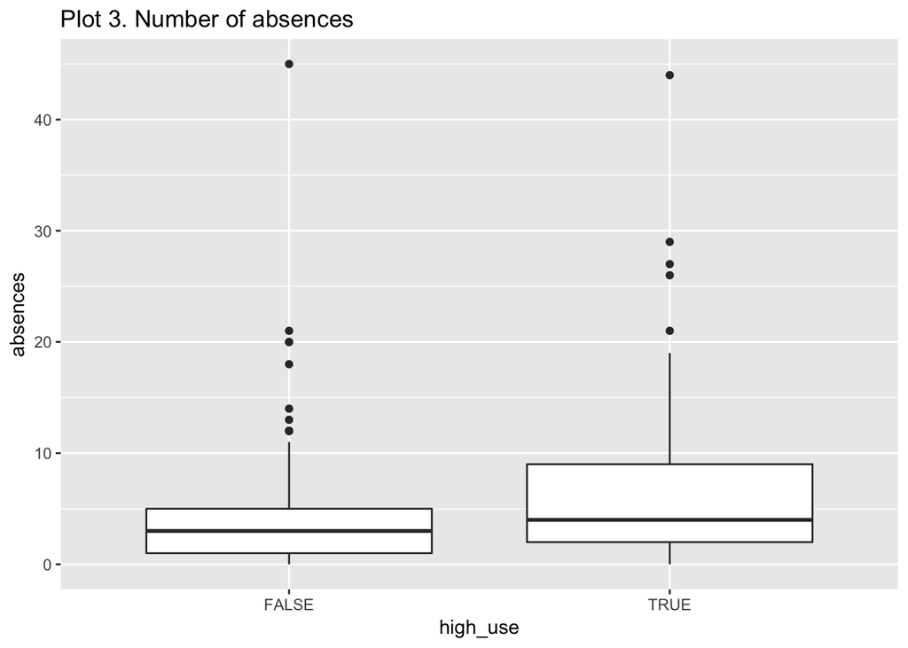

```r
# boxplot ABSENCES
g2 <- ggplot(ALC, aes(y =absences, x=high_use))
g2 + geom_boxplot() + ggtitle("Plot 3. Number of absences")
```

Table 3 shows the mean absences which seem to differ between high and low users, so that the ones who have high alcohol consumption have almost two times more absences compared to the ones with low alcohol consumption. This can be observed also from the plot 3. These support the alternative hypothese about high users having more absences.

```r
#table 4
ALC %>% group_by(high_use) %>% summarise(count = n(), mean_weekly_study_time=mean(studytime))
```

```
## # A tibble: 2 × 3
##   high_use count mean_weekly_study_time
##      <lgl> <int>                  <dbl>
## 1    FALSE   268               2.149254
## 2     TRUE   114               1.771930
```

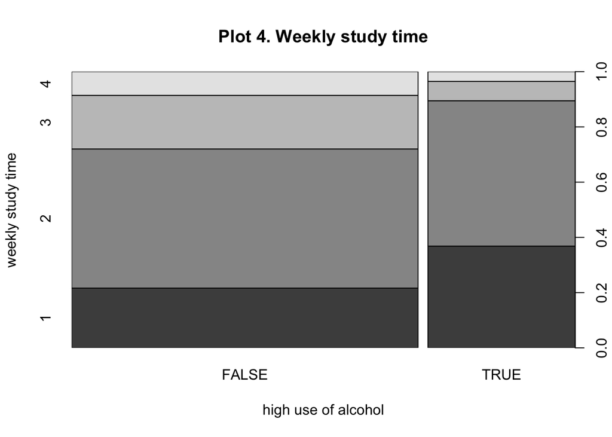

```r
# barplot STUDYTIME
spineplot(factor(studytime)~factor(high_use), xlab="high use of alcohol", ylab="weekly study time", main="Plot 4. Weekly study time")
```

Table 4. shows that the ones with low alcohol consumption uses on average more hours to study per week than the ones with high consumption. Difference can be seen in the plot 4. This suggests that the null hypothesis could possibly be rejected. To confirm these findings, they need to be tested also statistically.